# STAT 631 ROS Chapter3: Probability Basics

Prof. Kapitula

9/14/2021

```r
# Load all packages here:
library(tidyverse)
library(dplyr)
library(ggplot2)
# Set seed value of random number generator to get "replicable" random numbers.
# The choice of seed value of 76 was an arbitrary one on my part.
set.seed(76)
```

## Weighted Averages

We can enter vectors using code like below in R.

```r
stratum=1:3
country=c('United States','Mexico','Canada')
population=c(310,112,34)
averageAge=c(36.8,26.7,40.7)
#put vectors in a tibble to display
tibble(stratum,country,population,averageAge)
```

```
## # A tibble: 3 x 4
##   stratum country       population averageAge
##     <int> <chr>              <dbl>      <dbl>
## 1       1 United States        310       36.8
## 2       2 Mexico               112       26.7
## 3       3 Canada                34       40.7
```

To compute a weighted average in R, we can do the below:

```r
#the wrong way
averageNA=(population/sum(population))*averageAge
averageNA
```

```
## [1] 25.017544  6.557895  3.034649
```

```r
averageNA=(population/sum(population))%*%averageAge
round(averageNA,1)
```

```
##      [,1]
## [1,] 34.6
```

##Vectors and Matrices

```r
x1=c(-1,0,1)
x0=rep(1,3)
X = matrix(c(x0,x1),3,2)
X
```

```
##      [,1] [,2]
## [1,]    1   -1
## [2,]    1    0
## [3,]    1    1
```

```r
betahat=c(46.3,3.0)
yhat=X%*%betahat
yhat
```

```
##      [,1]
## [1,] 43.3
## [2,] 46.3
## [3,] 49.3
```

##Graphing a Function such as a Line in R

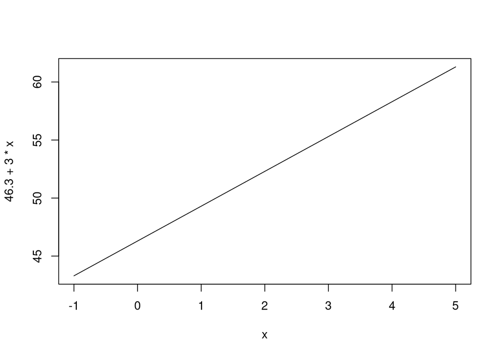

```r
curve(46.3+3.0*x, from=-1, to=5)
```

## Introducing Probability

Today we will introduce some probability basics.

### Five Key Facts About Probability

1. Probabilities are between 0 and 1.
2. Something that happens with probability 1 is a sure thing.
3. If something has no chance of occurring, it has probability 0.
4. If something has probability $p$ of happening it is has probability $1-p$ of not happening.
5. If two items are mutually exclusive, the probability one or the other of them happen is the sum of their probabilities.

note: We have to assume something always occurs in our random experiment, and that all the probabilities add up to one.

## Independence

Example: consider a population with the proportions below, S=small height, M=medium height, T=tall, Bl=blue eyes, Br=brown eyes, G=Green eyes.

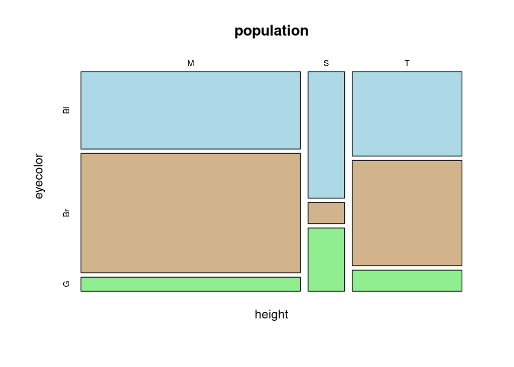

```r
poptable=tribble(
  ~height, ~eyecolor,  ~p,
 "T", "Bl",  .12,
"T", "Br", .15,
"T", "G", .03,
"M", "Bl", .22,
"M", "Br", .34,
"M", "G",  .04,
"S", "Bl",  .06,
"S", "Br",  .01,
"S", "G",  .03)
poptable <- poptable %>%
  mutate(p1000=p*1000)

population = poptable %>%
  uncount(p1000) #uncount takes a frequency variable and
#replicates the data that many times and keeps all the #other variables in the data
mosaicplot(height~eyecolor, data=population,
           color=c('lightblue','tan','lightgreen'))
```

Two events $A$ and $B$ are independent if
$$P(A \cap B)=P(A)P(B)$$

Are the events a person is medium height and a person has blue eyes independent? Why or why not?

** answer here

## Random Variables

A random variable is a function that equates outcomes from a random experiment with numbers. For example the number of dots on the upside if we roll a die. Lets see how we can simulate from such a random variable.

```r
dice = 1:6
sample(x = dice, size = 1, replace = TRUE)
```

```
## [1] 5
```

```r
sims=sample(x = dice, size = 1000, replace = TRUE)
table(sims)/length(sims)
```

```
## sims
##     1     2     3     4     5     6
## 0.167 0.168 0.176 0.160 0.181 0.148
```

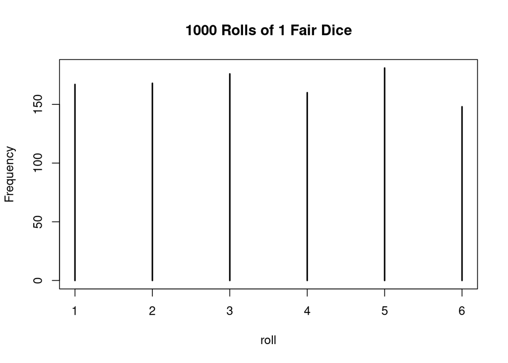

```r
plot(table(sims), xlab = 'roll', ylab = 'Frequency', main = '1000 Rolls of 1 Fair Dice')
```

This is an example of a discrete random variable, as it has countable values. We can use our simulation to get an idea of what would happen in the long run.

Calculate the mean and variance for the random variable X, the value on the top of a 4 sided die.

Note that if two random variables are independent it implies that the the covariance is necessarily 0. However, a covariance of 0 does not necessarily imply two variables are independent, remember covariance and correlation only measure the strength of the linear relationship.

Many variables can not be exactly measured, like height, weight, etc. We can only measure them to within a certain interval. So theoretically we also need continuous random variables. The most famous of the continuous RVs is the Normal Distribution.  
\

The probability density function for the standard normal distribution is:
$$f(x)= \frac{1}{\sqrt{2\pi}}e^{-x^2/2}$$

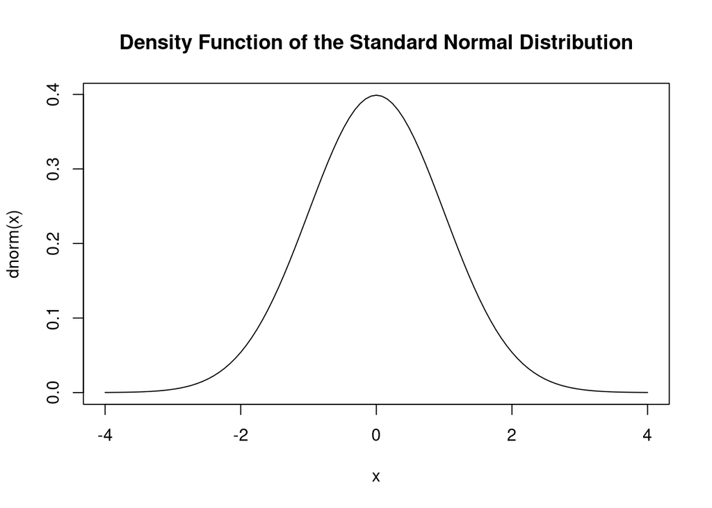

```r
curve(dnorm(x), from=-4, to=4, main="Density Function of the Standard Normal Distribution")
```